# Biomarker Discovery

Load *PharmacoGx* into your current workspace:

```r
suppressPackageStartupMessages({
  require(BiocManager) || install.packages("BiocManager")
  require(PharmacoGx) || install("PharmacoGx")
  require(Biobase) || install("Biobase")
  require(devtools) || install.packages("devtools")
  require(glmnet) || install.packages("Hmisc")
  require(glmnet) || install.packages("glmnet")
  require(wCI) || install_github("bhklab/wCI")
  require(PharmacoGxML) || install_github("bhklab/PharmacoGxML")
  require(xtable) || install.packages("xtable")

})
```

### Downloading PharmacoSet objects

We have made the PharmacoSet objects of the curated datasets available for download using functions provided in the package. A table of available PharmacoSet objects can be obtained by using the *availablePSets* function. Any of the PharmacoSets in the table can then be downloaded by calling *downloadPSet*, which saves the datasets into a directory of the users choice, and returns the data into the R session.

```r
  availablePSets(saveDir=file.path(".", "Safikhani_Pharmacogenomics"))
  GDSC <- downloadPSet("GDSC", saveDir=file.path(".", "PSets"))
  CCLE <- downloadPSet("CCLE", saveDir=file.path(".", "PSets"))
```

### consistency assessment improved by Modified Concordance Index

To better assess the concordance of multiple pharmacogenomic studies we introduced the modified concordance index (wCI). Recognizing that the noise in the drug screening assays is high and may yield to inaccurate sensitive-based ranking of cell lines with close AAC values, the wCI only considers cell line pairs with drug sensitivity (AAC) difference greater than $\delta$ .

```r
c_index <-  mc_index <- NULL
common <- intersectPSet(pSets = list("CCLE"=CCLE, "GDSC"=GDSC),
                        intersectOn = c("cell.lines", "drugs"),
                        strictIntersect = TRUE)
```

```
## Intersecting large PSets may take a long time ...
```

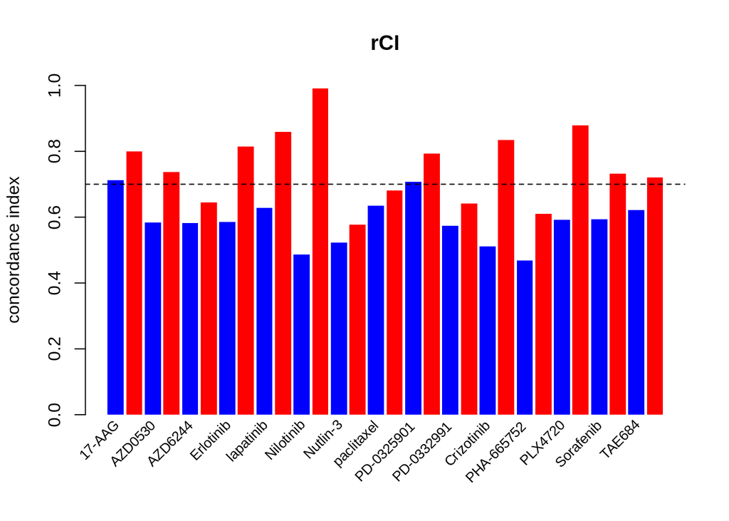

```r
drugs <- drugNames(common$CCLE)

GDSC.aac <- PharmacoGx::summarizeSensitivityProfiles(
    pSet=common$GDSC,
    sensitivity.measure='auc_recomputed',
    summary.stat="median",
    verbose=FALSE)
CCLE.aac <- PharmacoGx::summarizeSensitivityProfiles(
  pSet=common$CCLE,
  sensitivity.measure='auc_recomputed',
  summary.stat="median",
  verbose=FALSE)

for(drug in drugs){
  tt <- wCI::paired.concordance.index(GDSC.aac[drug,], CCLE.aac[drug,], delta.pred=0, delta.obs=0, alternative="greater")
  c_index <- c(c_index, tt$cindex)
  tt <- wCI::paired.concordance.index(GDSC.aac[drug,], CCLE.aac[drug,], delta.pred=0.2, delta.obs=0.2, alternative="greater", logic.operator="or")
  mc_index <- c(mc_index, tt$cindex)
}
mp <- barplot(as.vector(rbind(c_index, mc_index)), beside=TRUE, col=c("blue", "red"), ylim=c(0, 1), ylab="concordance index", space=c(.15,.85), border=NA, main="rCI")
text(mp, par("usr")[3], labels=as.vector(rbind(drugs, rep("", 15))), srt=45, adj=c(1.1,1.1), xpd=TRUE, cex=.8)
abline(h=.7, lty=2)
```

### Known Biomarkers

The association between molecular features and response to a given drug is modelled using a linear regression model adjusted for tissue source:
$$Y = \beta_{0} + \beta_{i}G_i + \beta_{t}T + \beta_{b}B$$
where $Y$ denotes the drug sensitivity variable, $G_i$, $T$ and $B$ denote the expression of gene $i$, the tissue source and the experimental batch respectively, and $\beta$s are the regression coefficients. The strength of gene-drug association is quantified by $\beta_i$, above and beyond the relationship between drug sensitivity and tissue source. The variables $Y$ and $G$ are scaled (standard deviation equals to 1) to estimate standardized coefficients from the linear model. Significance of the gene-drug association is estimated by the statistical significance of $\beta_i$ (two-sided t test). P-values are then corrected for multiple testing using the false discovery rate (FDR) approach.

As an example of the reproducibility of biomarker discovery across pharmacogenomic studies, we can model the significance of the association between two drugs and their known biomarkers in CCLE and GDSC. We examine the association between drug *Erlotinib* and gene *EGFR*, as well as drug *PD-0325901* and gene *BRAF*:

```r
  features <- PharmacoGx::fNames(CCLE, "rna")[
    which(featureInfo(CCLE,
                      "rna")$Symbol == "EGFR")]
    ccle.sig.rna <- PharmacoGx::drugSensitivitySig(pSet=CCLE,
                                  mDataType="rna",
                                  drugs=c("Erlotinib"),
                                  features=features,
                                  sensitivity.measure="auc_published",
                                  molecular.summary.stat="median",
                                  sensitivity.summary.stat="median",
                                  verbose=FALSE)
    gdsc.sig.rna <- PharmacoGx::drugSensitivitySig(pSet=GDSC,
                                  mDataType="rna",
                                  drugs=c("Erlotinib"),
                                  features=features,
                                  sensitivity.measure="auc_published",
                                  molecular.summary.stat="median",
                                  sensitivity.summary.stat="median",
                                  verbose=FALSE)
    ccle.sig.mut <- PharmacoGx::drugSensitivitySig(pSet=CCLE,
                                  mDataType="mutation",
                                  drugs=c("PD-0325901"),
                                  features="BRAF",
                                  sensitivity.measure="auc_published",
                                  molecular.summary.stat="and",
                                  sensitivity.summary.stat="median",
                                  verbose=FALSE)
    gdsc.sig.mut <- drugSensitivitySig(pSet=GDSC,
                                  mDataType="mutation",
                                  drugs=c("PD-0325901"),
                                  features="BRAF",
                                  sensitivity.measure="auc_published",
                                  molecular.summary.stat="and",
                                  sensitivity.summary.stat="median",
                                  verbose=FALSE)
    ccle.sig <- rbind(ccle.sig.rna, ccle.sig.mut)
    gdsc.sig <- rbind(gdsc.sig.rna, gdsc.sig.mut)
    known.biomarkers <- cbind("GDSC effect size"=gdsc.sig[,1],
                              "GDSC pvalue"=gdsc.sig[,6],
                              "CCLE effect size"=ccle.sig[,1],
                              "CCLE pvalue"=ccle.sig[,6])
    rownames(known.biomarkers) <- c("Erlotinib + EGFR","PD-0325901 + BRAF")

    #xtable(known.biomarkers, digits=c(0, 2, -1, 2, -1), caption='Concordance of biomarkers across stuudies')
    head(known.biomarkers)
    par(mfrow=c(2, 2))
    CCLE_expr <- t(exprs(PharmacoGx::summarizeMolecularProfiles(CCLE, mDataType="rna", fill.missing=FALSE)))
    CCLE_cells <- intersect(rownames(CCLE_expr), colnames(CCLE.aac))
    plot(CCLE.aac["Erlotinib", CCLE_cells], CCLE_expr[CCLE_cells, features],
         main="CCLE + Erlotinib + EGFR",
         cex.main=1, ylab="Predictions", xlab="drug sensitivity", pch=20, col="gray40")

    GDSC_expr <- t(exprs(PharmacoGx::summarizeMolecularProfiles(GDSC, mDataType="rna", fill.missing=FALSE)))
```

[output not shown]

```
## Summarizing rna molecular data for:  GDSC
```

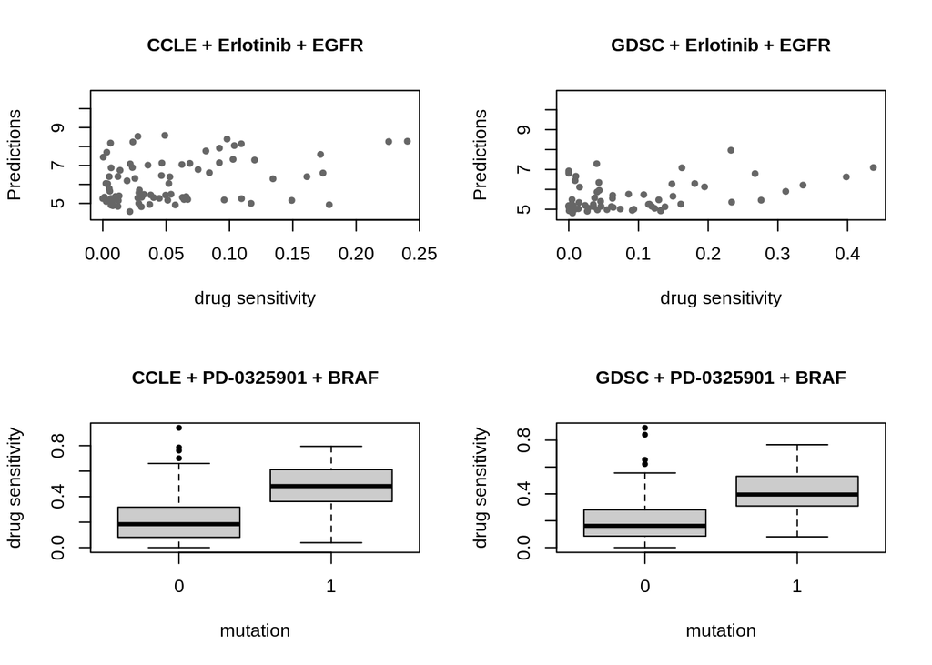

```r
    GDSC_cells <- intersect(rownames(GDSC_expr), colnames(GDSC.aac))
    plot(GDSC.aac["Erlotinib", GDSC_cells], GDSC_expr[GDSC_cells, features],
         main="GDSC + Erlotinib + EGFR",
         cex.main=1, ylab="Predictions", xlab="drug sensitivity", pch=20, col="gray40")

    CCLE_mut <- t(exprs(PharmacoGx::summarizeMolecularProfiles(CCLE, mDataType="mutation", fill.missing=FALSE, summary.stat="or")))
    CCLE_cells <- intersect(rownames(CCLE_mut), colnames(CCLE.aac))
    boxplot(CCLE.aac["PD-0325901", CCLE_cells]~ CCLE_mut[CCLE_cells, "BRAF"], col="gray80", pch=20, main="CCLE + PD-0325901 + BRAF",
            cex.main=1, xlab="mutation", ylab="drug sensitivity")

    GDSC_mut <- t(exprs(PharmacoGx::summarizeMolecularProfiles(GDSC, mDataType="mutation", fill.missing=FALSE, summary.stat="or")))
    GDSC_cells <- intersect(rownames(GDSC_mut), colnames(GDSC.aac))
    boxplot(GDSC.aac["PD-0325901", GDSC_cells]~ GDSC_mut[GDSC_cells, "BRAF"], col="gray80", pch=20, main="GDSC + PD-0325901 + BRAF",
            cex.main=1, xlab="mutation", ylab="drug sensitivity")
```

## Machine Learning and Biomarker Discovery

Some of the widely used multivariate machine learning methods such as elastic net, Random Forest (RF) and Support Vector Machine (SVM) have been already implemented in the MLWorkshop. It optimizes hyperparameters of these methods in the training phase. To assess the performance of the predictive models, it implements *m* number of sampling with *n-fold* cross validations (CV). The performance will then be assessed by multiple metrics including pearson correlation coefficient, concordance index and modified concordance index.

```r
suppressPackageStartupMessages({
  require(mRMRe) ||  install.packages("mRMRe")
  require(caret) || install.packages("caret")
  require(randomForest) || install.packages("randomForest")
})
##Preparing trainig dataset
train_expr <- t(exprs(PharmacoGx::summarizeMolecularProfiles(GDSC, mDataType="rna", fill.missing=FALSE, verbose=FALSE)))
aac <- PharmacoGx::summarizeSensitivityProfiles(GDSC, sensitivity.measure="auc_recomputed", drug="lapatinib", fill.missing=FALSE, verbose=FALSE)
cells <- intersect(rownames(train_expr), names(aac))
df <- as.matrix(cbind(train_expr[cells,], "lapatinib"=aac[cells]))


##Preparing validation dataset
validation_expr <- PharmacoGx::summarizeMolecularProfiles(CCLE, mDataType="rna", fill.missing=FALSE, verbose=FALSE)
actual_labels <- PharmacoGx::summarizeSensitivityProfiles(CCLE, sensitivity.measure="auc_recomputed", drug="lapatinib", fill.missing=FALSE, verbose=FALSE)


for(method in c("ridge", "lasso", "random_forest", "svm")){
  par(mfrow=c(1, 2))
  res <- PharmacoGxML::optimization(train=df[, -ncol(df), drop=F],
                      labels=t(df[, ncol(df), drop=F]),
                      method=method,
                      folds.no=5,
                      sampling.no=1,
                      features.no=10,
                      feature.selection="mRMR",
                      assessment=c("corr", "rCI"))

  validation_labels <- PharmacoGxML::validation(model=res$model$lapatinib,
                                  validation.set=t(exprs(validation_expr)),
                                  validation.labels=actual_labels,
                                  method=method,
                                  assessment="rCI")

}
```

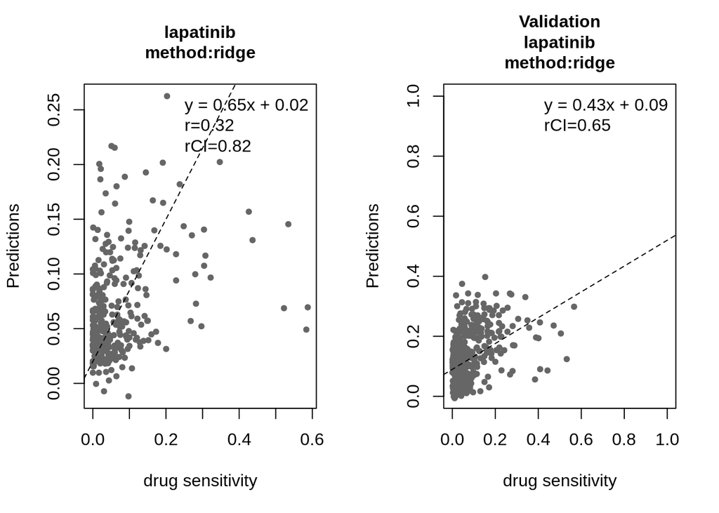

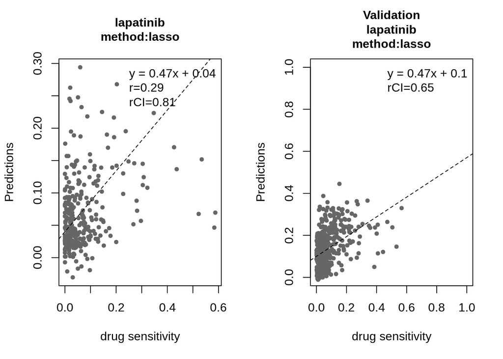

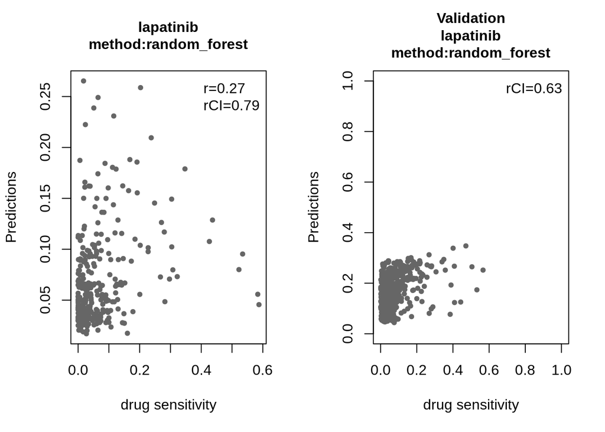

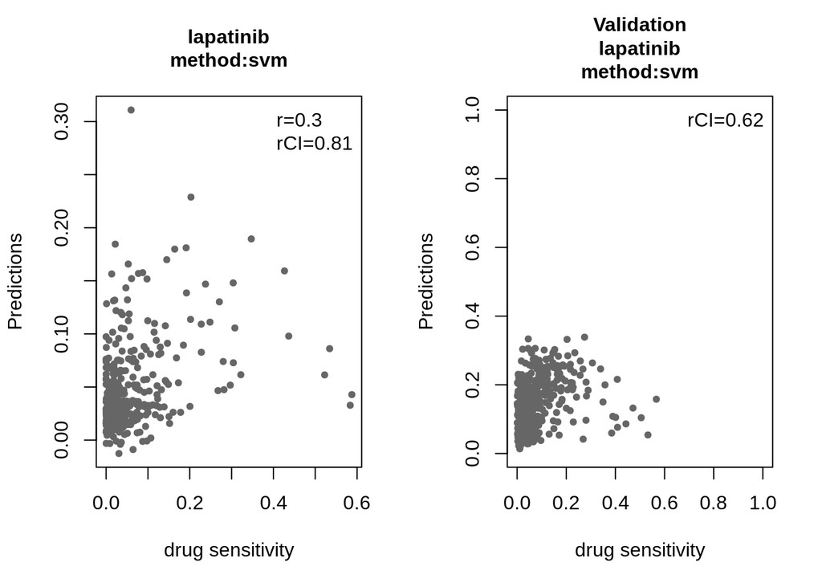